# RIO Day 12: Statistics

NSF Bay Area Microbiome RaMP

### (1) Welcome

Welcome to the RIO Day 12 workshop! We will introduce you to foundational statistics and data analysis using R.

Follow along on slides here: https://docs.google.com/presentation/d/1rSXje8xby3ud9a9EiWlYwLaaTW81jHc-xfD41IO4I50/edit?usp=sharing

### (2) Icebreaker

**Task:** In this icebreaker activity, you will interview three classmates and collect data. Please fill in your cohort survey data here:

Fill in your cohort survey data here: https://docs.google.com/spreadsheets/d/1M5XoRXIcGKRkmndYhlKOdsE7nYyKHZUXhdq1AbA_qyc/edit?usp=sharing

### (3) Why Statistics?

(see slideshow link at #1 above)

Statistics plays a crucial role in understanding biological questions. We’ll discuss equity in statistics and the importance of decolonizing data science practices.

What’s one biological question you’d love to answer with data? Dream big!

### (4) Data Visualization

(see slideshow link at #1 above)

We will now cover data visualization to help communicate insights effectively. Good visualizations are essential for making sense of complex datasets.

We’ll explore some visualizations such as bar plots and scatter plots. You can follow along with interactive visualizations at pudding.cool.

### (5) RStudio

In this section, we will install **R** and **RStudio**, which are essential tools for our work in data analysis and statistics. You will also get a quick introduction to RStudio’s layout.

First, install R and RStudio on your computer, if you haven’t already. Once installed, we’ll tour the RStudio interface and perform basic operations.

```r
1 + 1
```

```
## [1] 2
```

### (6) Inference Basics

Before diving into hypothesis testing, we need to understand the concept of **distributions** and **normality**. This is the foundation for most statistical tests.

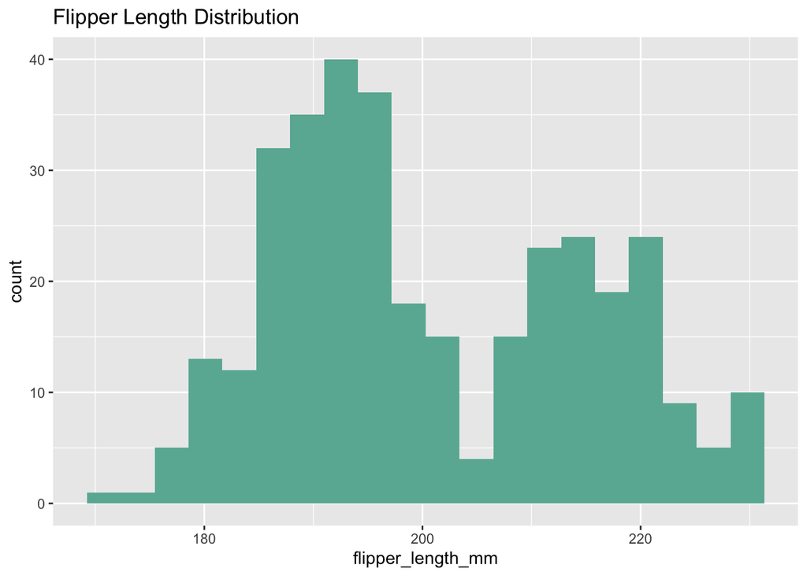

```r
# Let's perform a t-test to compare the flipper lengths of Adelie and Chinstrap penguins and see if the difference is statistically significant.
# Let's visualize the distribution of flipper length for the penguins dataset and test its normality.
# Example of distribution check using penguins dataset
penguins |>
  ggplot(aes(x = flipper_length_mm)) +
  geom_histogram(fill = '#69b3a2', bins = 20) +
  labs(title = 'Flipper Length Distribution')
```

Sometimes datasets need a little cleaning up, and there are packages for that. Let’s clean up the names.

```r
# clean names
pg <- penguins |>
  janitor::clean_names() |>
  filter(!is.na(bill_length_mm), !is.na(flipper_length_mm))
```

To eyeball normality of each group, draw histograms:

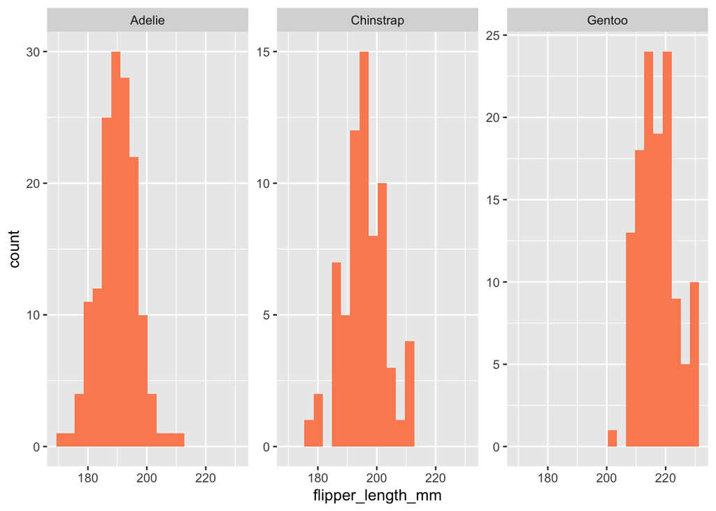

```r
hists <- pg |>
  ggplot(aes(x = flipper_length_mm)) +
  geom_histogram(fill = "#FC8D62", bins = 20) +
  facet_wrap(~ species, scales = "free_y")

hists
```

Does the distribution appear normal based on the histogram? How does the distribution of flipper length vary across species? Does it appear normal for all species?

Filter the dataset for Adelie and Chinstrap penguins and perform a Shapiro test to check for normality.

```r
# focus on two groups for normality examples
pg2 <- pg |>
  filter(species %in% c("Adelie","Chinstrap"))

# extract vectors
adelie    <- pg2 |> filter(species == "Adelie")    |> pull(flipper_length_mm)
chinstrap <- pg2 |> filter(species == "Chinstrap") |> pull(flipper_length_mm)

# Run Shapiro-Wilk test for normality for all data (without sampling)
pg2 |>
  group_by(species) |>
  summarise(
    n = sum(!is.na(flipper_length_mm)),   # Count of non-missing values
    shapiro_p = shapiro.test(flipper_length_mm)$p.value  # Shapiro-Wilk test for normality
  )
```

```
## # A tibble: 2 × 3
##   species       n shapiro_p
##   <fct>     <int>     <dbl>
## 1 Adelie      151     0.720
## 2 Chinstrap    68     0.811
```

What do the p-values from the Shapiro-Wilk test tell you about the normality of the data for each species?

### (7) Hypothesis Testing

In this section, we will introduce **hypothesis testing** using the **t-test**. The t-test compares the means of two groups and helps us determine if the difference is statistically significant.

**Task**: We will test if there is a significant difference between the flipper lengths of **Adelie** and **Chinstrap** penguins. First, let’s perform a t-test and interpret the p-value.

```r
# Let's perform a t-test to compare the flipper lengths of Adelie and Chinstrap penguins and see if the difference is statistically significant.
# Let's visualize the distribution of flipper length for the penguins dataset and test its normality.
# Example of t-test with penguins dataset
penguins_subset <- penguins |> filter(species %in% c('Adelie', 'Chinstrap'))
t.test(flipper_length_mm ~ species, data = penguins_subset)
```

```
##
##  Welch Two Sample t-test
##
## data:  flipper_length_mm by species
## t = -5.7804, df = 119.68, p-value = 6.049e-08
## alternative hypothesis: true difference in means between group Adelie and group Chinstrap is not equal to 0
## 95 percent confidence interval:
##  -7.880530 -3.859244
## sample estimates:
##    mean in group Adelie mean in group Chinstrap
##                189.9536                195.8235
```

Based on the p-value from the t-test, do you reject or fail to reject the null hypothesis? What does this tell us about the difference in flipper lengths?

### (8) ANOVAs

The **ANOVA** (Analysis of Variance) is an extension of the t-test that compares means across more than two groups. We’ll also briefly discuss **PERMANOVA**, a method for comparing groups based on distance matrices. **Task**: Let’s compare the flipper lengths of different penguin species using one-way **ANOVA**.

```r
aov_res <- aov(flipper_length_mm ~ species, data = pg)
summary(aov_res)
```

```
##              Df Sum Sq Mean Sq F value Pr(>F)
## species       2  52473   26237   594.8 <2e-16 ***
## Residuals   339  14953      44
## ---
## Signif. codes:  0 '***' 0.001 '**' 0.01 '*' 0.05 '.' 0.1 ' ' 1
```

What is the p-value from the ANOVA? What does it tell us about the differences in flipper lengths across penguin species?

#### (8a) Boxplot with ANOVA p-values

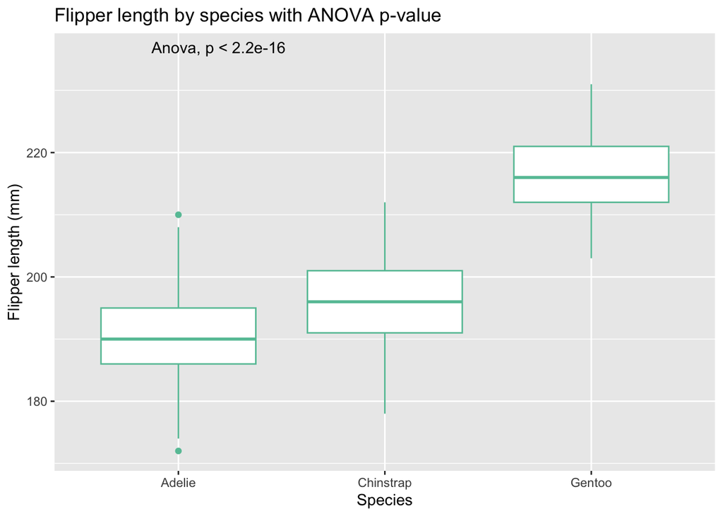

```r
p_base <- pg |>
  ggplot(aes(x = species, y = flipper_length_mm)) +
  geom_boxplot(color = "#66C2A5") +
  labs(title = "Flipper length by species with ANOVA p-value",
       x = "Species", y = "Flipper length (mm)")

# dynamic placement to avoid clipping
ylab_top <- max(pg$flipper_length_mm, na.rm = TRUE) + 5

p_base + stat_compare_means(method = "anova", label.y = ylab_top)
```

#### (8b) Posthoc pairwise tests

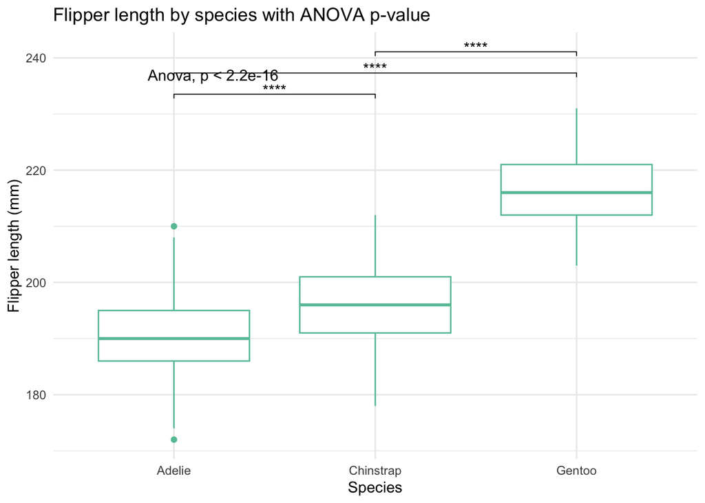

```r
pw <- pg |>
  tukey_hsd(flipper_length_mm ~ species) |>
  add_xy_position(x = "species")

p_base +
  stat_compare_means(method = "anova", label.y = ylab_top) +
  stat_pvalue_manual(pw, hide.ns = TRUE, tip.length = 0.01) +
  theme_minimal()
```

#### (8c) Stacked bar chart (composition)

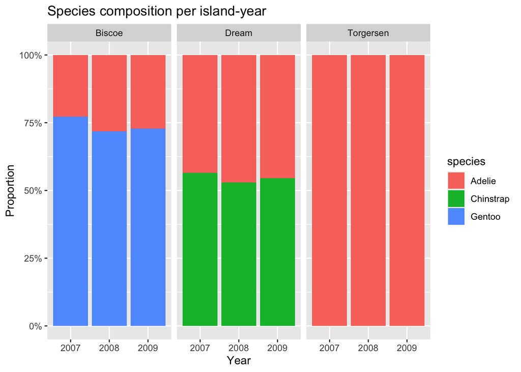

```r
comp <- pg |>
  count(island, year, species, name = "abundance") |>
  group_by(island, year) |>
  mutate(prop = abundance / sum(abundance)) |>
  ungroup()

comp |>
  ggplot(aes(x = factor(year), y = prop, fill = species)) +
  geom_col(position = "fill") +
  facet_wrap(~ island, nrow = 1) +
  scale_y_continuous(labels = scales::percent) +
  labs(title = "Species composition per island-year",
       x = "Year", y = "Proportion")
```

#### (8d) PERMANOVA

```r
abund_mat <- pg |>
  count(island, year, species) |>
  tidyr::pivot_wider(names_from = species, values_from = n, values_fill = 0)

meta <- abund_mat |>
  select(island, year)

X <- abund_mat |>
  select(-island, -year) |>
  as.data.frame()

D <- vegdist(X, method = "bray")
set.seed(42)
adonis2(D ~ island, data = meta, permutations = 999)
```

```
## Permutation test for adonis under reduced model
## Terms added sequentially (first to last)
## Permutation: free
## Number of permutations: 999
##
## adonis2(formula = D ~ island, data = meta, permutations = 999)
##          Df SumOfSqs      R2      F Pr(>F)
## island    2  1.03582 0.96543 83.775  0.004 **
## Residual  6  0.03709 0.03457
## Total     8  1.07291 1.00000
## ---
## Signif. codes:  0 '***' 0.001 '**' 0.01 '*' 0.05 '.' 0.1 ' ' 1
```

### (9) Correlation & Regression

#### (9a) Correlation

**Correlation measures** the relationship between two variables. We’ll calculate the **Pearson correlation** between **bill length** and **flipper length**.

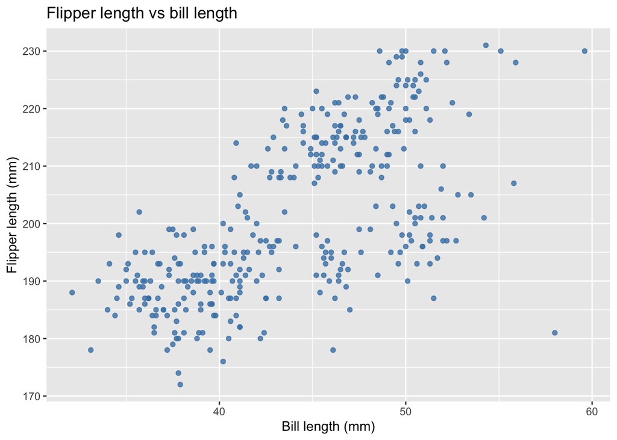

```r
pg |>
  ggplot(aes(x = bill_length_mm, y = flipper_length_mm)) +
  geom_point(alpha = 0.8, color = "steelblue") +
  labs(title = "Flipper length vs bill length",
       x = "Bill length (mm)", y = "Flipper length (mm)")
```

```r
# tidy formula interface
cor.test(~ bill_length_mm + flipper_length_mm, data = pg, method = "pearson")
```

```
##
##  Pearson's product-moment correlation
##
## data:  bill_length_mm and flipper_length_mm
## t = 16.034, df = 340, p-value < 2.2e-16
## alternative hypothesis: true correlation is not equal to 0
## 95 percent confidence interval:
##  0.5912769 0.7126403
## sample estimates:
##       cor
## 0.6561813
```

What does the correlation coefficient tell you about the relationship between bill length and flipper length?

#### (9b) Regression

**Regression** allows us to predict one variable based on another. In this section, we will perform a **linear regression** to model **flipper length** as a function of **bill length**.

**Task:** Let’s fit a regression line and interpret the slope and R².

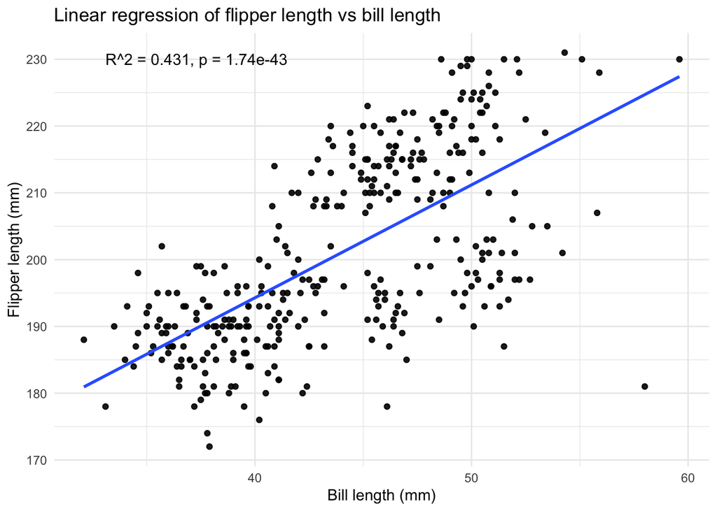

```r
m <- lm(flipper_length_mm ~ bill_length_mm, data = pg)
sumstats <- summary(m)

regplot <- pg |>
  ggplot(aes(bill_length_mm, flipper_length_mm)) +
  geom_point(alpha = 0.9) +
  geom_smooth(method = "lm", se = FALSE)

r2   <- sumstats$r.squared |> round(3)
pval <- sumstats$coefficients[2,4] |> signif(3)

ann_pos <- pg |>
  summarise(x = min(bill_length_mm, na.rm = TRUE) + 1,
            y = max(flipper_length_mm, na.rm = TRUE) - 1)

regplot +
  theme_minimal() +
  labs(title = "Linear regression of flipper length vs bill length",
       x = "Bill length (mm)", y = "Flipper length (mm)") +
  annotate("text", x = ann_pos$x, y = ann_pos$y,
           label = glue::glue("R^2 = {r2}, p = {pval}"), hjust = 0)
```

### (10) Generalized Linear Models (GLMs)

**Generalized Linear Models** (GLMs) extend linear regression models to handle binary, count, or other types of outcomes. We’ll introduce **logistic regression** here.

Let’s fit a logistic regression model using **sex** as a **binary outcome**.

```r
pg_glm <- pg |>
  filter(!is.na(sex)) |>
  mutate(sex = droplevels(sex), sex_bin = ifelse(sex == "male", 1, 0))

glm_fit <- glm(sex_bin ~ bill_length_mm + bill_depth_mm,
               data = pg_glm, family = binomial)
summary(glm_fit)
```

```
##
## Call:
## glm(formula = sex_bin ~ bill_length_mm + bill_depth_mm, family = binomial,
##     data = pg_glm)
##
## Coefficients:
##                 Estimate Std. Error z value Pr(>|z|)
## (Intercept)    -24.94444    2.89052  -8.630  < 2e-16 ***
## bill_length_mm   0.27107    0.03567   7.600 2.97e-14 ***
## bill_depth_mm    0.76716    0.09709   7.901 2.76e-15 ***
## ---
## Signif. codes:  0 '***' 0.001 '**' 0.01 '*' 0.05 '.' 0.1 ' ' 1
##
## (Dispersion parameter for binomial family taken to be 1)
##
##     Null deviance: 461.61  on 332  degrees of freedom
## Residual deviance: 323.64  on 330  degrees of freedom
## AIC: 329.64
##
## Number of Fisher Scoring iterations: 5
```

### (11) Cohort Data

In this section, we’ll analyze the cohort survey data you collected earlier. You will clean the data as needed, create visualizations, and perform basic statistical analyses such as hypothesis testing and correlation.

**Task:** Load the data, clean it, and perform the necessary analysis.

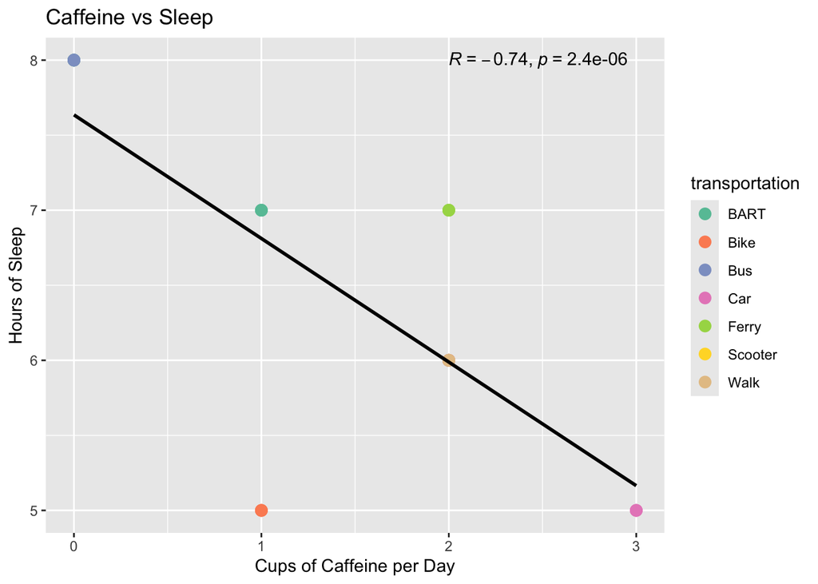

```r
# load cohort data
cohortdata <- read.csv("cohortdata - data.csv", stringsAsFactors = T)

# plot
cohortdata |>
  ggplot(aes(x = caffeine, y = sleep, color = transportation)) +
  geom_point(size = 3) +
  geom_smooth(method = "lm", se = FALSE, color = "black") +
  stat_cor(method = "pearson", label.x = 2, label.y = 8, color = "black") +   # correlation + p-value
  scale_color_brewer(palette = "Set2") +
  labs(title = "Caffeine vs Sleep",
       x = "Cups of Caffeine per Day",
       y = "Hours of Sleep")
```

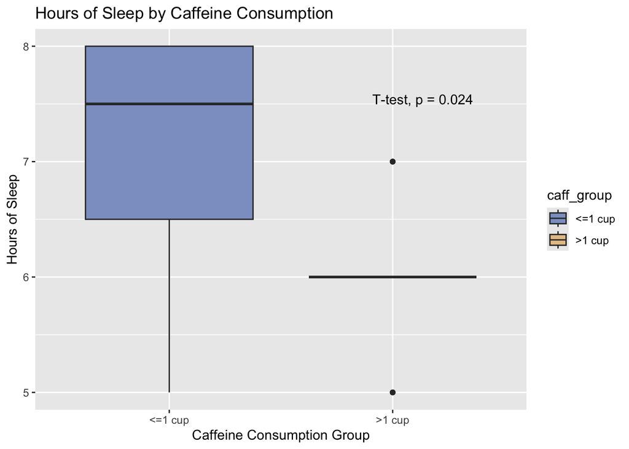

```r
cohortdata |>
  mutate(caff_group = if_else(caffeine > 1, ">1 cup", "<=1 cup")) |>
  ggplot(aes(x = caff_group, y = sleep, fill = caff_group)) +
  geom_boxplot() +
  stat_compare_means(method = "t.test",
                     label.x = 2,
                     label.y = 7.5) +   # adds p-value
  labs(title = "Hours of Sleep by Caffeine Consumption",
       x = "Caffeine Consumption Group",
       y = "Hours of Sleep") +
  scale_fill_manual(values = c("#8DA0CB", "#E5C494"))
```

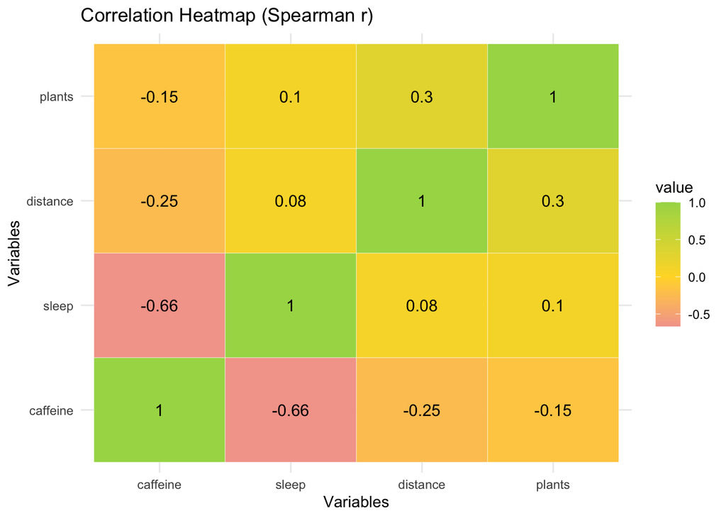

```r
# Select numeric variables
numeric_vars <- cohortdata |> select(caffeine, sleep, distance, plants)

# Calculate Spearman correlation for each pair
cor_results <- cor(numeric_vars, use = "complete.obs", method = "spearman")

# Reshape the correlation matrix to long format
cor_results_melt <- melt(cor_results)

# Create heatmap plot
ggplot(cor_results_melt, aes(Var1, Var2, fill = value)) +
  geom_tile(color = "white") +
  geom_text(aes(label = round(value, 2)), color = "black", size = 4) +  # Adding correlation values with adjusted font size
  scale_fill_gradient2(low = "#E78AC3", high = "#A6D854", mid = "#FFD92F", midpoint = 0) +
  labs(title = "Correlation Heatmap (Spearman r)",
       x = "Variables",
       y = "Variables") +
  theme(axis.text.x = element_text(angle = 45, hjust = 1)) +  # Rotate x-axis labels for better readability
  theme_minimal()  # Cleaner background
```

```r
cohort2 <- cohortdata |>
  mutate(caff_group = if_else(caffeine > 1, ">1 cup", "<=1 cup")) |>
  filter(!is.na(distance), !is.na(caff_group))

# Perform t-test
t.test(distance ~ caff_group, data = cohort2)
```

```
##
##  Welch Two Sample t-test
##
## data:  distance by caff_group
## t = -2.0486, df = 21.585, p-value = 0.05285
## alternative hypothesis: true difference in means between group <=1 cup and group >1 cup is not equal to 0
## 95 percent confidence interval:
##  -1082.238887     7.238887
## sample estimates:
## mean in group <=1 cup  mean in group >1 cup
##                 267.5                 805.0
```

```r
# Perform Spearman correlation
cor.test(cohortdata$plants, cohortdata$distance, method = "spearman", use = "complete.obs")
```

```
##
##  Spearman's rank correlation rho
##
## data:  cohortdata$plants and cohortdata$distance
## S = 3125.7, p-value = 0.1017
## alternative hypothesis: true rho is not equal to 0
## sample estimates:
##       rho
## 0.3046168
```

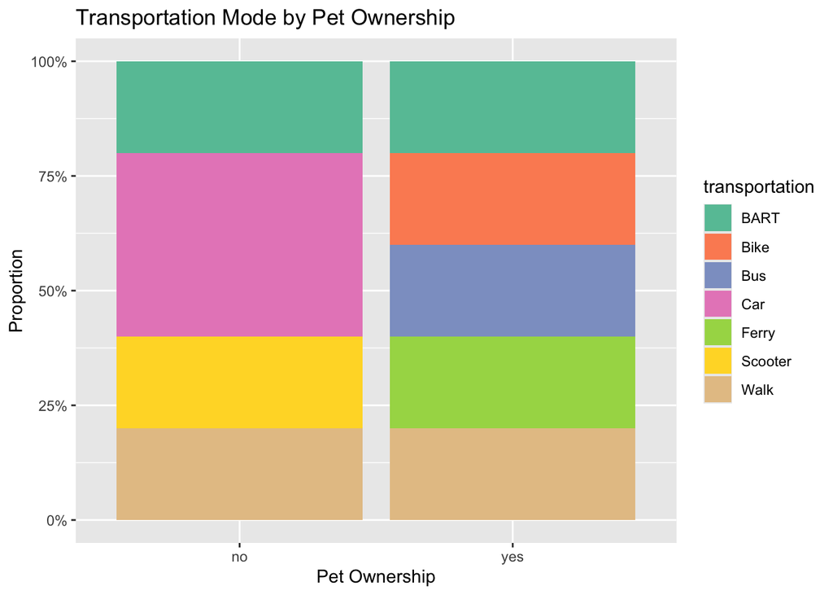

```r
# Plot
cohortdata |>
  ggplot(aes(x = pet, fill = transportation)) +
  geom_bar(position = "fill") +
  labs(title = "Transportation Mode by Pet Ownership",
       x = "Pet Ownership",
       y = "Proportion") +
  scale_y_continuous(labels = scales::percent) +
  scale_fill_brewer(palette = "Set2")  # Use ColorBrewer Set2 palette
```

### (12) Wrap-Up

**Summary:** We’ve covered a variety of statistical methods, from data visualization to hypothesis testing and regression. Make sure to **choose the appropriate statistical test** for your data, and always visualize first.

After lunch, we will dive into genomic data analysis.

**Great work!**